# Proyecto final - Aprendizaje no supervisado (NBA)

Carlos Angel, José Donado, Diego Monroy, Carlos Aldana y Marco Carbajal

2025-05-25

# **Introducción**

Este documento presenta un análisis de un dataset con información (métricas de desempeño y características cualitativas) acerca de 50 jugadores de la NBA. El objetivo es explorar estos datos y aplicarles clusterización.

# **Transformación de datos**

### **1. Librerías**

Estas son las librerías que utiliza nuestro programa:

```r
library(dplyr)
library(fastDummies)
library(psych)
library(fmsb)
library(corrplot)
library(tidyr)
library(broom)
library(sigr)
library(ggplot2)
library(WVPlots)
library(Metrics)
library(e1071)
library(weights)
library(corrplot)
library(tidyverse)
library(rpart)
library(rpart.plot)
library(caret)
library(e1071)
library(readxl)
library(writexl)
library(lubridate)
library(arules)
library(purrr)
library(cluster)
library(dendextend)
```

### **2. Espacio de trabajo**

```r
#setwd("C:/Users/carlo/OneDrive/Escritorio/data mining/Proyecto_2/Proyecto_unsupervised_learning")
#setwd("C:/Users/josep/OneDrive - UVG/SEMESTRE V/Data Mining/PROYECTO_FINAL_GITHUB/Proyecto_unsupervised_learning")
#setwd("C:/Users/dmonr/Downloads")
#setwd("C:/Users/Carlo/OneDrive/Escritorio/DM/Proyecto02")
#setwd("C:/Users/carba/OneDrive/Documents/AA UVG/Año 3, Ciclo 1/Data mining and machine learning/Proyecto final")
```

### **3. Importar los datos**

```r
df <- read.csv("nba_players_2023_clustering (1).csv")
```

### **4. Adición de variables (columnas)**

Se sugiere agregar una columna que describa la región a la que pertenece cada jugador, así como un campo que indique la habilidad del jugador (nivel de jugador) en función del rendimiento por minuto.

```r
df <- df %>%
  mutate(region = case_when(
    nationality == "USA" ~ "America del Norte",
    nationality == "Canada" ~ "America del Norte",
    nationality == "Mexico" ~ "America del Norte",
    nationality == "Australia" ~ "Oceania",
    nationality == "USA/Australia" ~ "America del Norte / Oceania",
    nationality == "Japan" ~ "Asia",
    nationality == "Finland" ~ "Europa",
    nationality == "Greece" ~ "Europa",
    nationality == "Nigeria" ~ "Africa",
    nationality == "Cameroon" ~ "Africa",
    TRUE ~ "Otra"))

df <- df %>%
  mutate(rendimiento_por_minuto = (points_per_game +
                                    assists_per_game +
                                    rebounds_per_game) / minutes_played_per_game)

df <- df %>%
  mutate(nivel_jugador = case_when(
    rendimiento_por_minuto >= 1.2 ~ "Elite",
    rendimiento_por_minuto >= 1.0 ~ "Alto",
    rendimiento_por_minuto >= 0.75 ~ "Promedio",
    rendimiento_por_minuto >= 0.6 ~ "Bajo",
    TRUE ~ "Muy bajo"
  ))

df$nivel_jugador <- factor(df$nivel_jugador,
                           levels = c("Muy bajo", "Bajo", "Promedio", "Alto", "Elite"))
```

Además, se creó una columna que indica la conferencia a la que pertenece cada equipo.

```r
equipos <- c(
  "Orlando Magic", "Milwaukee Bucks", "Washington Wizards", "Phoenix Suns",
  "Miami Heat", "Milwaukee Bucks", "Philadelphia 76ers", "New York Knicks",
  "Sacramento Kings", "Washington Wizards", "Toronto Raptors", "Milwaukee Bucks",
  "Boston Celtics", "Boston Celtics", "New York Knicks", "Orlando Magic",
  "Utah Jazz", "Phoenix Suns", "Dallas Mavericks", "Los Angeles Lakers",
  "Oklahoma City Thunder", "Oklahoma City Thunder", "Golden State Warriors",
  "Dallas Mavericks", "Atlanta Hawks", "Chicago Bulls", "Phoenix Suns",
  "Charlotte Hornets", "Sacramento Kings", "Utah Jazz", "New York Knicks",
  "Oklahoma City Thunder", "Miami Heat", "Dallas Mavericks", "Memphis Grizzlies",
  "Los Angeles Clippers", "Dallas Mavericks", "Atlanta Hawks", "Brooklyn Nets",
  "Detroit Pistons", "Philadelphia 76ers", "San Antonio Spurs", "Dallas Mavericks",
  "Dallas Mavericks", "Chicago Bulls", "Boston Celtics", "Phoenix Suns",
  "Los Angeles Lakers", "Atlanta Hawks", "Phoenix Suns")

# Crear columna conferencia
df <- df %>%
  mutate(conferencia = case_when(
    team %in% c("Orlando Magic", "Milwaukee Bucks", "Washington Wizards",
                "Miami Heat", "Philadelphia 76ers", "New York Knicks",
                "Toronto Raptors", "Boston Celtics", "Atlanta Hawks",
                "Chicago Bulls", "Charlotte Hornets", "Brooklyn Nets",
                "Detroit Pistons") ~ "Eastern Conference",
    team %in% c("Phoenix Suns", "Sacramento Kings", "Utah Jazz",
                "Dallas Mavericks", "Los Angeles Lakers", "Oklahoma City Thunder",
                "Golden State Warriors", "Memphis Grizzlies",
                "Los Angeles Clippers", "San Antonio Spurs") ~ "Western Conference",
    TRUE ~ NA_character_  # Por si hay algún equipo que no esté listado
  ))

write.csv(df, "NBA_data.csv", row.names = FALSE)
```

De esta forma, la cantidad de jugadores por conferencia quedó distribuida así:

```r
table(df$conferencia)
```

```
##
## Eastern Conference Western Conference
##                 26                 24
```

La Eastern Conference cuenta con 26 jugadores, mientras que la Western Conference cuenta con 24 jugadores.

# **Exploración del dataset**

Las siguientes preguntas de exploración tienen como objetivo entender a fondo el dataset con el que vamos a trabajar:

1. **¿Qué tipo de datos contiene?**

```r
str(df)
```

```
## 'data.frame':    50 obs. of  12 variables:
##  $ name                   : chr  "Admiral Schofield" "Damian Lillard" "Daniel Gafford" "Devin Booker" ...
##  $ age                    : int  25 32 24 26 25 25 28 23 32 26 ...
##  $ minutes_played_per_game: num  12.2 36.3 20.6 34.6 9.1 11.8 32.1 28.9 18.9 35.9 ...
##  $ rebounds_per_game      : num  1.7 4.8 5.6 4.5 1.5 2.3 11.8 4.2 3.8 6.9 ...
##  $ assists_per_game       : num  0.8 7.3 1.1 5.5 1.7 0.5 5.7 3.4 1.5 3.5 ...
##  $ points_per_game        : num  4.2 32.2 9 27.8 3.3 4.9 31.1 14.9 6.9 26.6 ...
##  $ team                   : chr  "Orlando Magic" "Milwaukee Bucks" "Washington Wizards" "Phoenix Suns" ...
##  $ nationality            : chr  "USA" "USA" "USA" "USA" ...
##  $ region                 : chr  "America del Norte" "America del Norte" "America del Norte" "America del Norte" ...
##  $ rendimiento_por_minuto : num  0.549 1.22 0.762 1.092 0.714 ...
##  $ nivel_jugador          : Factor w/ 5 levels "Muy bajo","Bajo",..: 1 5 3 4 2 2 5 3 2 4 ...
##  $ conferencia            : chr  "Eastern Conference" "Eastern Conference" "Eastern Conference" "Western Conference" ...
```

```r
glimpse(df)
```

```
## Rows: 50
## Columns: 12
## $ name                    <chr> "Admiral Schofield", "Damian Lillard", "Daniel…
## $ age                     <int> 25, 32, 24, 26, 25, 25, 28, 23, 32, 26, 24, 24…
## $ minutes_played_per_game <dbl> 12.2, 36.3, 20.6, 34.6, 9.1, 11.8, 32.1, 28.9,…
## $ rebounds_per_game       <dbl> 1.7, 4.8, 5.6, 4.5, 1.5, 2.3, 11.8, 4.2, 3.8, …
## $ assists_per_game        <dbl> 0.8, 7.3, 1.1, 5.5, 1.7, 0.5, 5.7, 3.4, 1.5, 3…
## $ points_per_game         <dbl> 4.2, 32.2, 9.0, 27.8, 3.3, 4.9, 31.1, 14.9, 6.…
## $ team                    <chr> "Orlando Magic", "Milwaukee Bucks", "Washingto…
## $ nationality             <chr> "USA", "USA", "USA", "USA", "USA", "Greece", "…
## $ region                  <chr> "America del Norte", "America del Norte", "Ame…
## $ rendimiento_por_minuto  <dbl> 0.5491803, 1.2203857, 0.7621359, 1.0924855, 0.…
## $ nivel_jugador           <fct> Muy bajo, Elite, Promedio, Alto, Bajo, Bajo, E…
## $ conferencia             <chr> "Eastern Conference", "Eastern Conference", "E…
```

```r
summary(df)
```

```
##      name                age        minutes_played_per_game rebounds_per_game
##  Length:50          Min.   :20.00   Min.   : 2.80           Min.   : 0.90
##  Class :character   1st Qu.:24.00   1st Qu.:16.18           1st Qu.: 3.00
##  Mode  :character   Median :25.00   Median :27.10           Median : 4.00
##                     Mean   :26.30   Mean   :24.62           Mean   : 4.55
##                     3rd Qu.:29.75   3rd Qu.:34.23           3rd Qu.: 5.05
##                     Max.   :38.00   Max.   :37.40           Max.   :11.80
##  assists_per_game points_per_game      team           nationality
##  Min.   : 0.100   Min.   : 1.600   Length:50          Length:50
##  1st Qu.: 1.200   1st Qu.: 6.125   Class :character   Class :character
##  Median : 1.750   Median :10.450   Mode  :character   Mode  :character
##  Mean   : 3.006   Mean   :14.580
##  3rd Qu.: 4.900   3rd Qu.:26.050
##  Max.   :10.200   Max.   :33.100
##     region          rendimiento_por_minuto  nivel_jugador conferencia
##  Length:50          Min.   :0.5442         Muy bajo: 9    Length:50
##  Class :character   1st Qu.:0.6113         Bajo    :18    Class :character
##  Mode  :character   Median :0.7133         Promedio: 6    Mode  :character
##                     Mean   :0.8411         Alto    :10
##                     3rd Qu.:1.0740         Elite   : 7
##                     Max.   :1.5140
```

El dataset analizado contiene información sobre 50 jugadores de la NBA, y está compuesto por 12 variables que combinan distintos tipos de datos. En primer lugar, incluye datos de tipo **numérico**, como la edad de los jugadores (*age*), los minutos jugados por partido (*minutes_played_per_game*), los rebotes (*rebounds_per_game*), asistencias (*assists_per_game*), puntos (*points_per_game*) y una métrica de rendimiento por minuto (*rendimiento_por_minuto*). Estas variables permiten realizar análisis cuantitativos sobre el desempeño individual de los jugadores. Por otro lado, se encuentran datos de tipo **carácter** como el nombre del jugador (*name*), el equipo (*team*), la nacionalidad (*nationality*), la región geográfica (*region*) y la conferencia (*conferencia*), que son útiles para identificar o agrupar a los jugadores según aspectos contextuales. Además, se incluye una variable de tipo **factor** categórico, *nivel_jugador*, que clasifica a los jugadores en categorías como “Muy bajo”, “Bajo”, “Promedio”, “Alto” y “Elite”, lo cual es relevante para segmentar el talento o el impacto de los jugadores.

2. **¿Cuál es la distribución de las variables?**

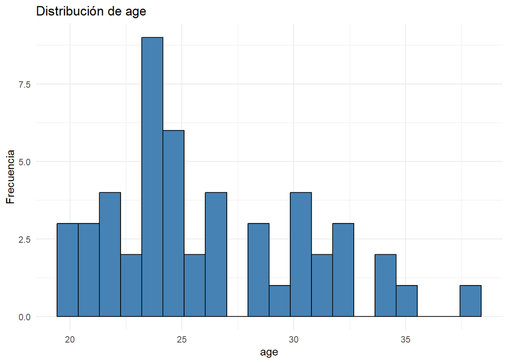

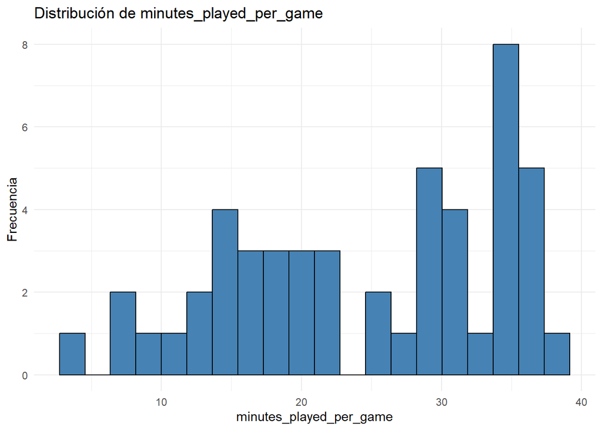

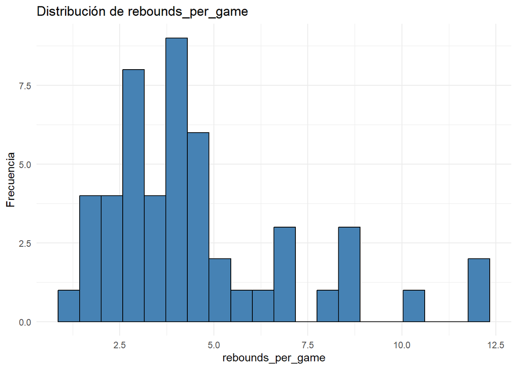

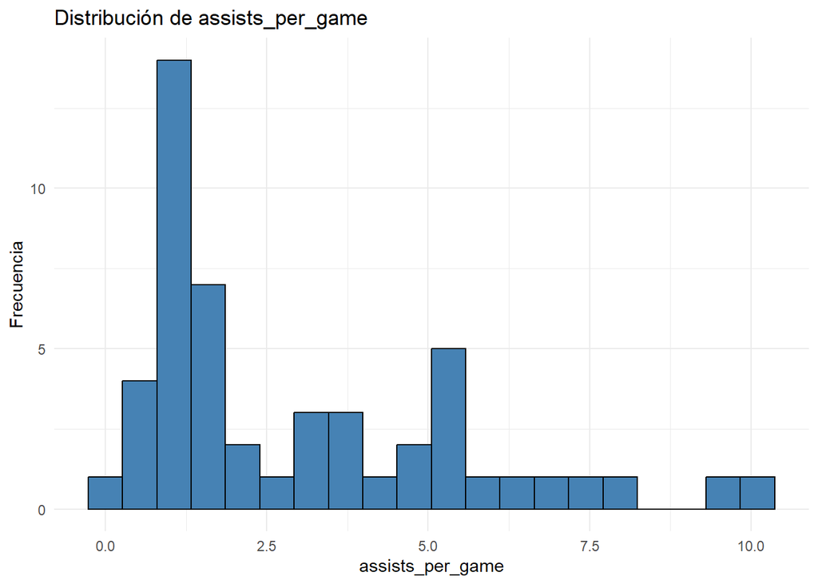

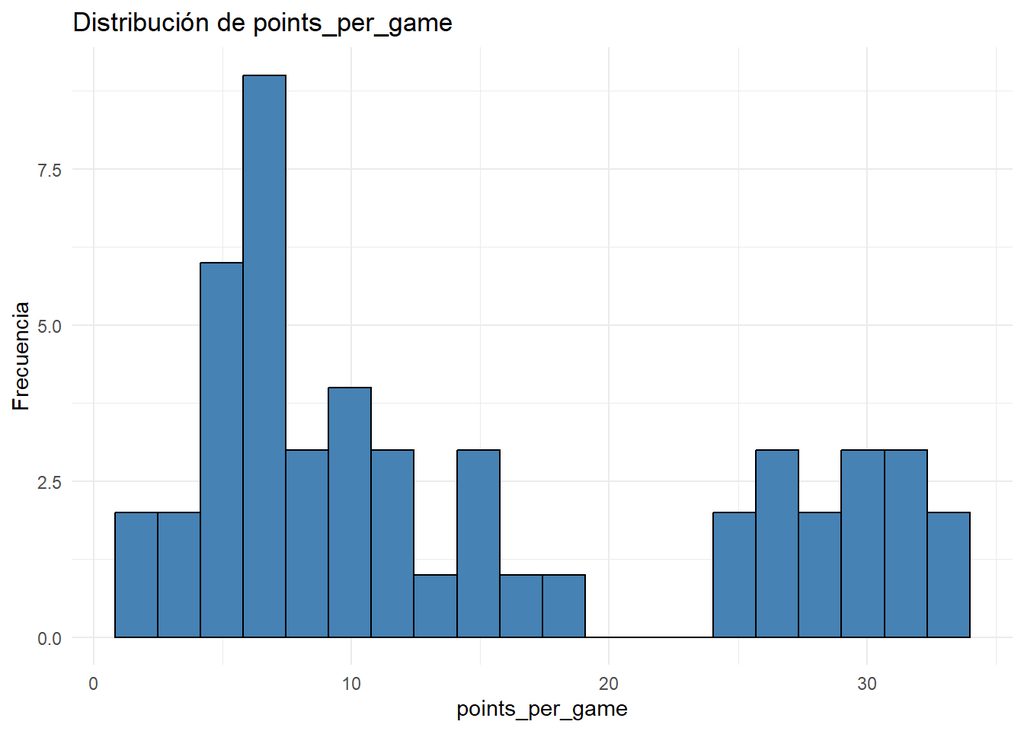

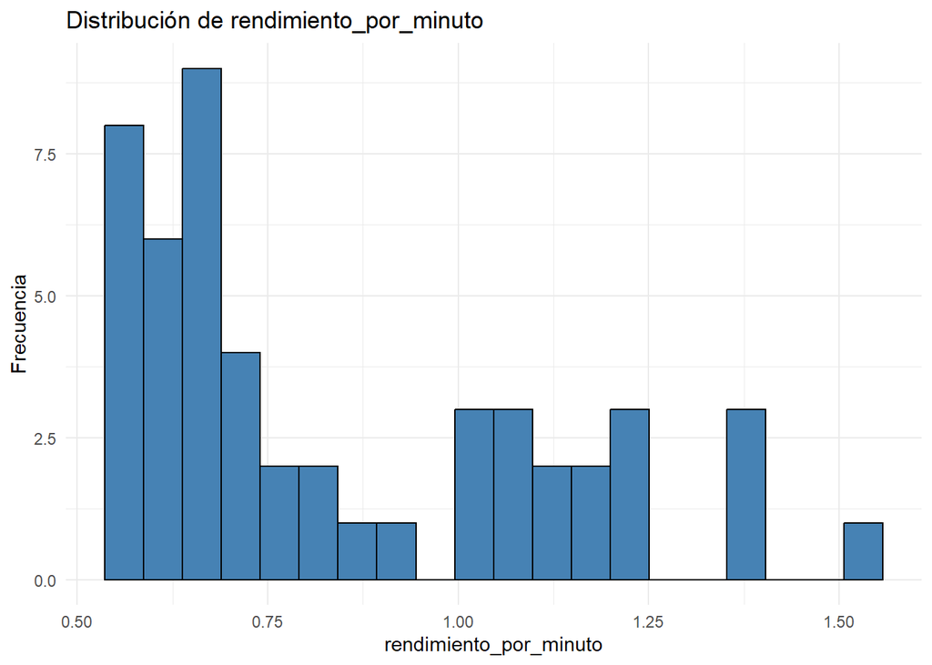

   ```r
   # 1. Detectar variables numéricas y gráficar histogramas
   numeric_vars <- names(df)[sapply(df, is.numeric)]
   for (var in numeric_vars) {
     print(
       ggplot(df, aes_string(x = var)) +
         geom_histogram(bins = 20, fill = "steelblue", color = "black") +
         theme_minimal() +
         labs(
           title = paste("Distribución de", var),
           x     = var,
           y     = "Frecuencia"
         )
     )
   }
   ```

   - **Distribución de *age***

   La mayoría de jugadores tiene entre 23 y 26 años, con un pico alrededor de 24–25. Hay pocos casos menores de 21 años y algunos mayores de 30 años, hasta los 38. La curva muestra ligera asimetría derecha por esos valores más altos.
   - **Distribución de *minutes_played_per_game***

   Se observa un agrupamiento en dos zonas: muchos jugadores rondan los 30–35 minutos, y otro grupo alrededor de 12–20 minutos. Hay pocos valores extremos muy bajos (<5 min) o muy altos (cercanos a 40 min). La forma sugiere una bi/multimodalidad por roles titulares vs. suplentes.
   - **Distribución de *rebounds_per_game***

   La mayoría anota entre 2 y 5 rebotes por partido, con frecuencia máxima cerca de 3–4. Aparecen pocos que superan los 7 rebotes y valores aislados alrededor de 10–12. La distribución está sesgada a la derecha por esos grandes reboteadores.
   - **Distribución de *assists_per_game***

   La concentración mayor está entre 1 y 2 asistencias, con varios valores entre 0–1 y un “colmillo” secundario alrededor de 5. Existen valores aislados hasta 10 asistencias. En general, asimetría derecha, pues pocos jugadores reparten asistencias muy altas.
   - **Distribución de *points_per_game***

   Se aprecia un grupo denso de jugadores promediando 5–10 puntos, y otro subconjunto (all‐stars) entre 25–35 puntos, generando una distribución bimodal. Hay pocos en rangos intermedios (10–20). Existe sesgo hacia la derecha por la “cola” de anotadores estrella.
   - **Distribución de *rendimiento_por_minuto***

   Hay dos concentraciones claras: un grupo con eficiencia baja-media (0.55–0.75) y otro con eficiencia alta (1.0–1.3). Unos pocos extremos superan 1.4. La forma es multimodal, indicando diferencias marcadas entre jugadores de rol y superestrellas.

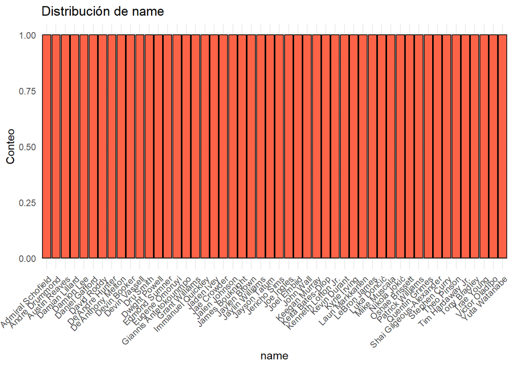

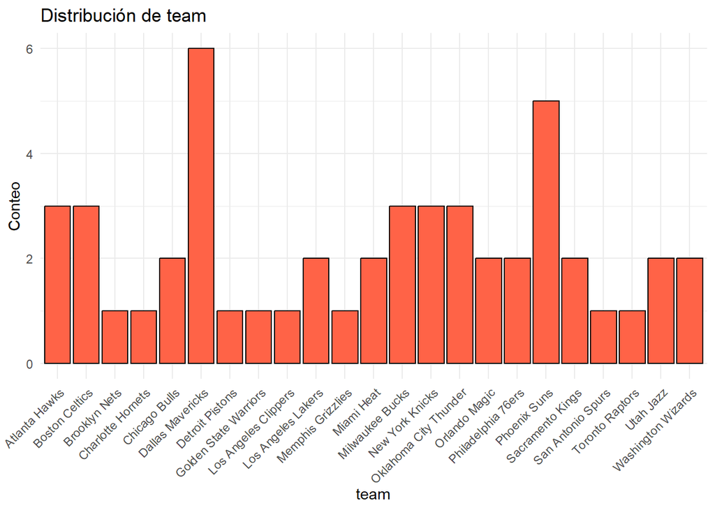

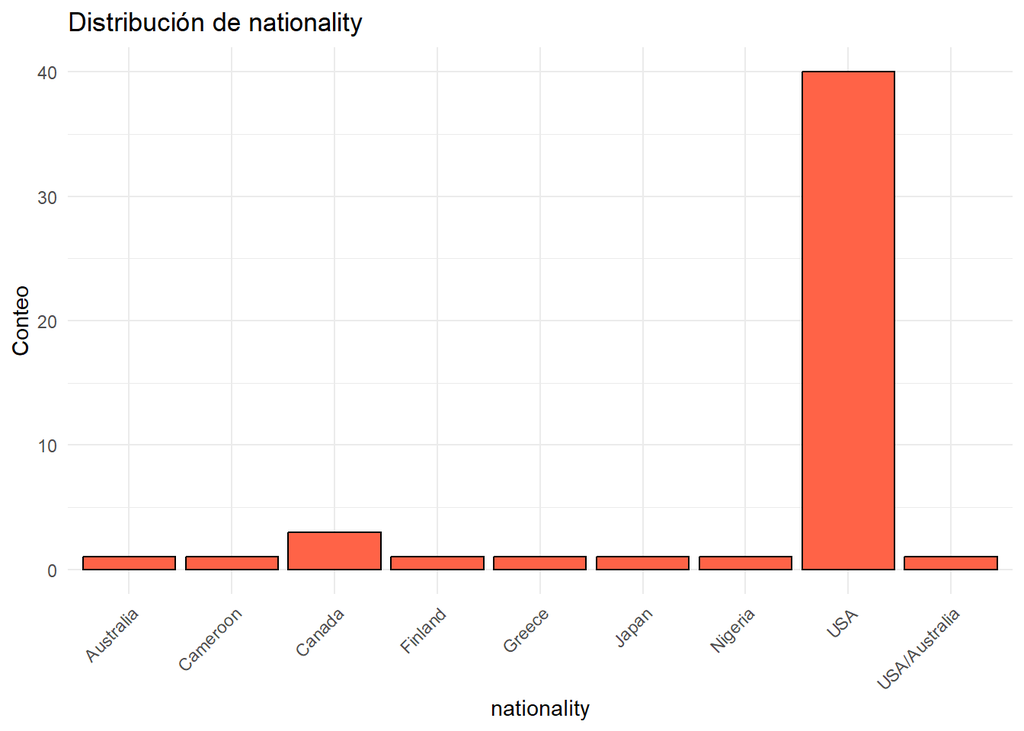

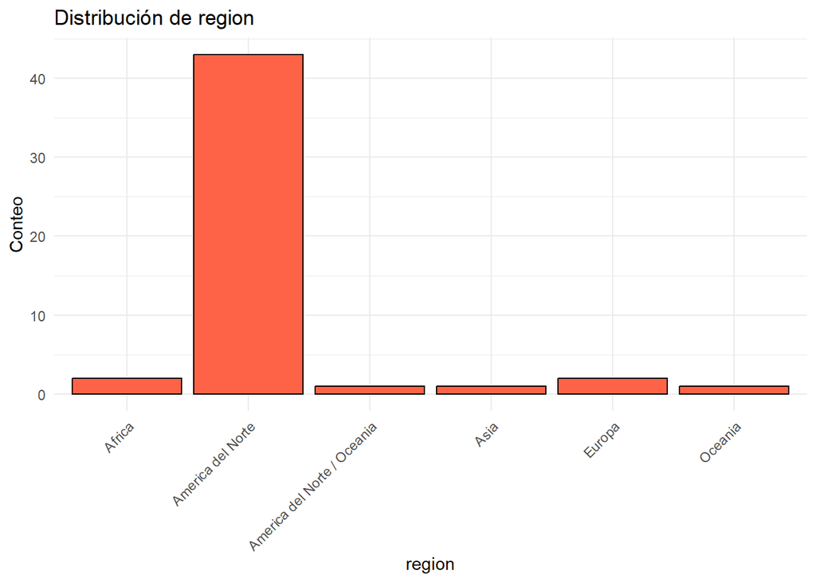

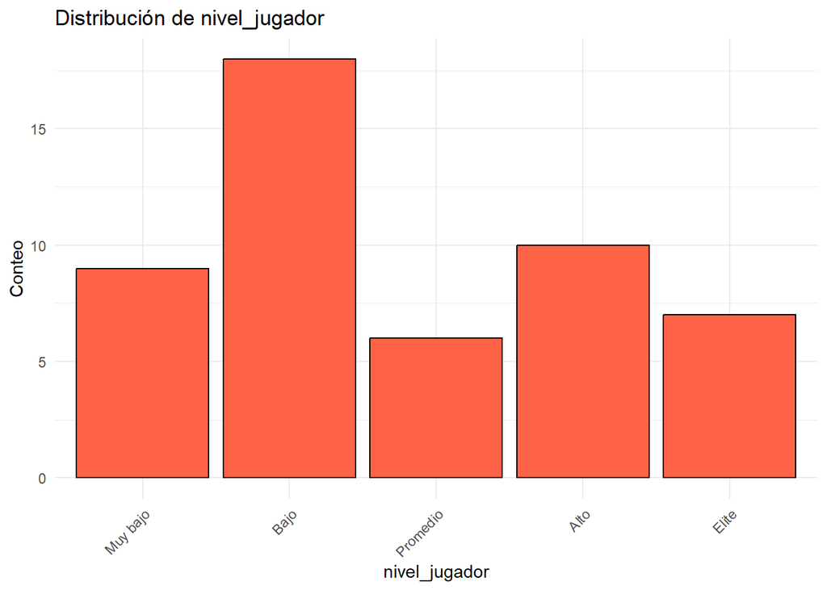

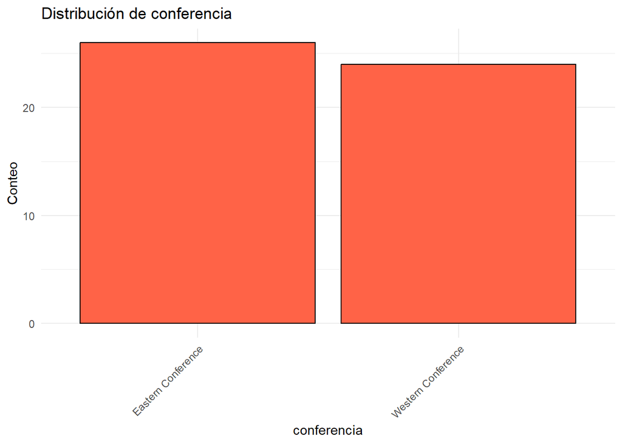

   ```r
   # 2. Detectar variables categóricas y gráficar diagramas de barras
   cat_vars <- names(df)[sapply(df, function(x) is.factor(x) || is.character(x))]
   for (var in cat_vars) {
     print(
       ggplot(df, aes_string(x = var)) +
         geom_bar(fill = "tomato", color = "black") +
         theme_minimal() +
         labs(
           title = paste("Distribución de", var),
           x     = var,
           y     = "Conteo"
         ) +
         theme(axis.text.x = element_text(angle = 45, hjust = 1))
     )
   }
   ```

   - **Distribución de *name***

   Cada barra representa un jugador único; todas las barras tienen altura 1. Esto confirma que no hay nombres repetidos: cada registro es de un solo jugador. La gráfica sirve más para verificar uniformidad que para “extraer tendencia”.
   - **Distribución de *team***

   Casi todos los jugadores proceden de “América del Norte” (≈42), con muy pocos de Europa, África, Asia u Oceanía (cada uno con 1–3). La región América del Norte es claramente mayoritaria, y las demás regiones apenas aportan jugadores.
   - **Distribución de *nivel_jugador***

   La categoría más frecuente es “Bajo” con 18 jugadores, seguida de “Alto” con 10. Hay 9 “Muy bajo”, 7 “Elite” y 6 “Promedio”. Esto indica que la mayoría se concentra en el rango “Bajo” y “Alto”, con menos jugadores en los extremos “Muy bajo” y “Elite”.
   - **Distribución de *conferencia***

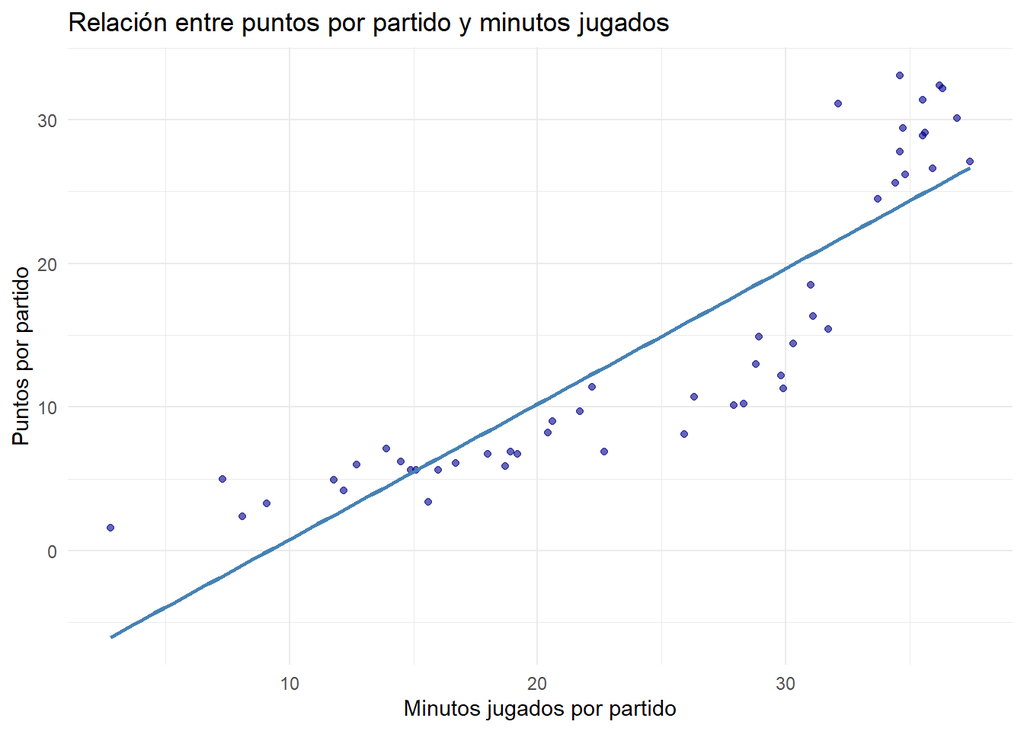

   ```r
   # 1. Puntos por partido vs. Minutos jugados
   ggplot(df, aes(x = minutes_played_per_game, y = points_per_game)) +
     geom_point(color = "darkblue", alpha = 0.6) +
     geom_smooth(method = "lm", se = FALSE, color = "steelblue") +
     theme_minimal() +
     labs(
       title = "Relación entre puntos por partido y minutos jugados",
       x     = "Minutos jugados por partido",
       y     = "Puntos por partido"
     )
   ```

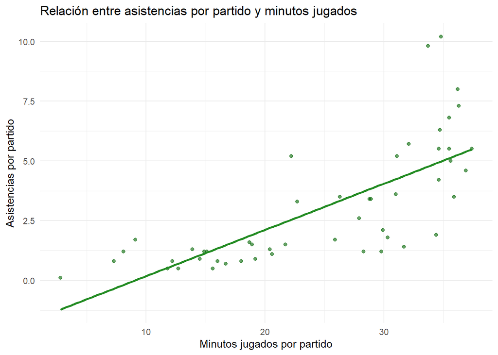

   ```r
   # 2. Asistencias por partido vs. Minutos jugados
   ggplot(df, aes(x = minutes_played_per_game, y = assists_per_game)) +
     geom_point(color = "darkgreen", alpha = 0.6) +
     geom_smooth(method = "lm", se = FALSE, color = "forestgreen") +
     theme_minimal() +
     labs(
       title = "Relación entre asistencias por partido y minutos jugados",
       x     = "Minutos jugados por partido",
       y     = "Asistencias por partido"
     )
   ```

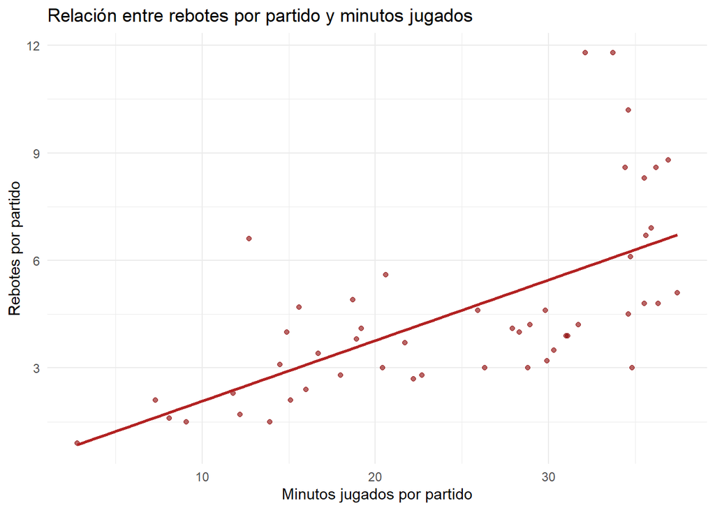

   ```r
   # 3. Rebotes por partido vs. Minutos jugados
   ggplot(df, aes(x = minutes_played_per_game, y = rebounds_per_game)) +
     geom_point(color = "darkred", alpha = 0.6) +
     geom_smooth(method = "lm", se = FALSE, color = "firebrick") +
     theme_minimal() +
     labs(
       title = "Relación entre rebotes por partido y minutos jugados",
       x     = "Minutos jugados por partido",
       y     = "Rebotes por partido"
     )
   ```

   - **Relación entre los puntos por partido y los minutos jugados**

   Se observa una correlación positiva muy marcada: a mayor tiempo en cancha, más puntos por juego. Los puntos aumentan casi linealmente con los minutos, indicando que los jugadores que juegan más suelen ser las principales opciones ofensivas.
   - **Relación entre las asistencias por partido y los minutos jugados**

   También existe una tendencia ascendente: quien juega más minutos tiende a repartir más asistencias, aunque el ajuste es algo más disperso que en puntos. La pendiente indica que, por cada 10 minutos adicionales, las asistencias crecen en promedio cerca de 1.5–2 pases de canasta.
   - **Relación entre los rebotes por partido y los minutos jugados**

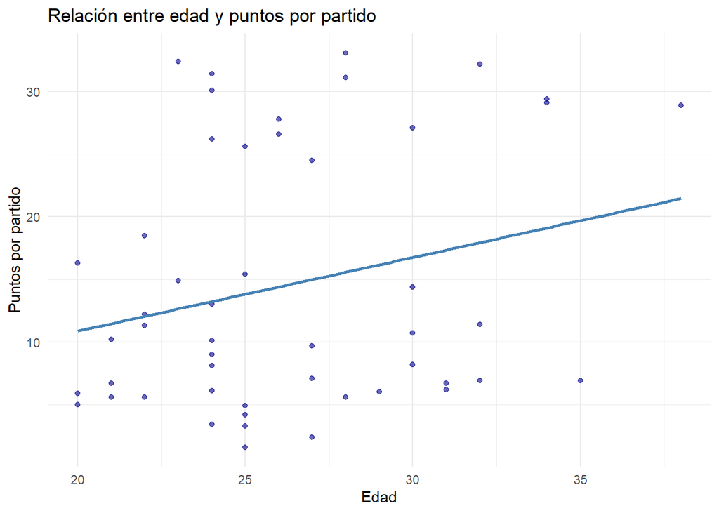

   ```r
   # Librería necesaria
   library(ggplot2)

   # 1. Puntos por partido vs. Edad
   ggplot(df, aes(x = age, y = points_per_game)) +
     geom_point(color = "darkblue", alpha = 0.6) +
     geom_smooth(method = "lm", se = FALSE, color = "steelblue") +
     theme_minimal() +
     labs(
       title = "Relación entre edad y puntos por partido",
       x     = "Edad",
       y     = "Puntos por partido"
     )
   ```

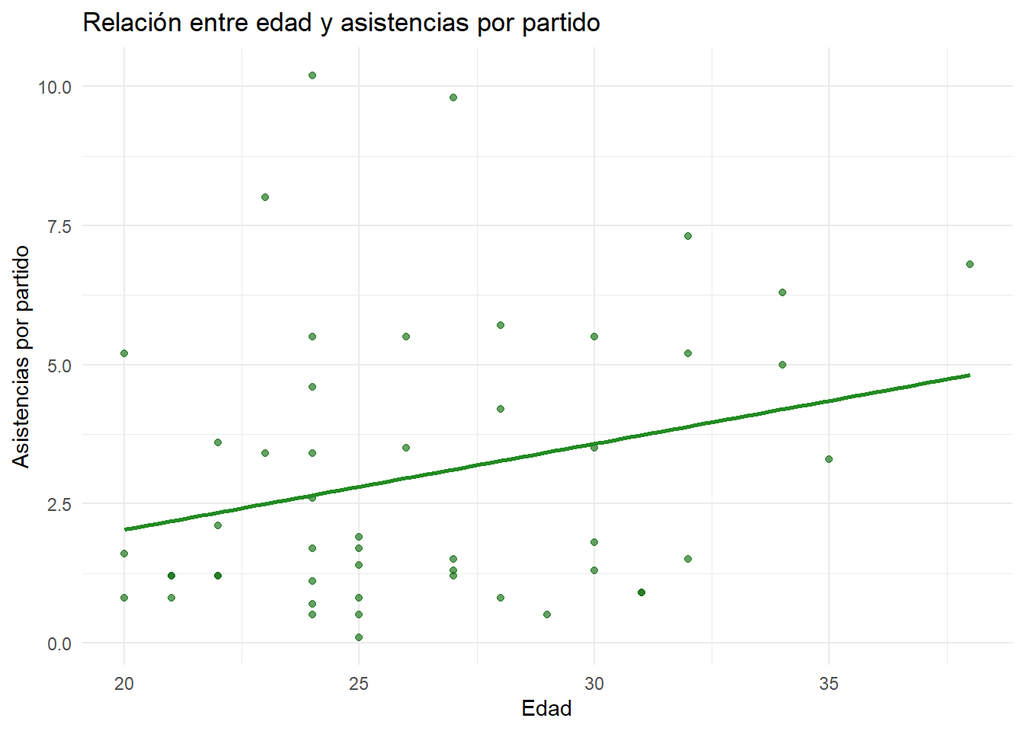

   ```r
   # 2. Asistencias por partido vs. Edad
   ggplot(df, aes(x = age, y = assists_per_game)) +
     geom_point(color = "darkgreen", alpha = 0.6) +
     geom_smooth(method = "lm", se = FALSE, color = "forestgreen") +
     theme_minimal() +
     labs(
       title = "Relación entre edad y asistencias por partido",
       x     = "Edad",
       y     = "Asistencias por partido"
     )
   ```

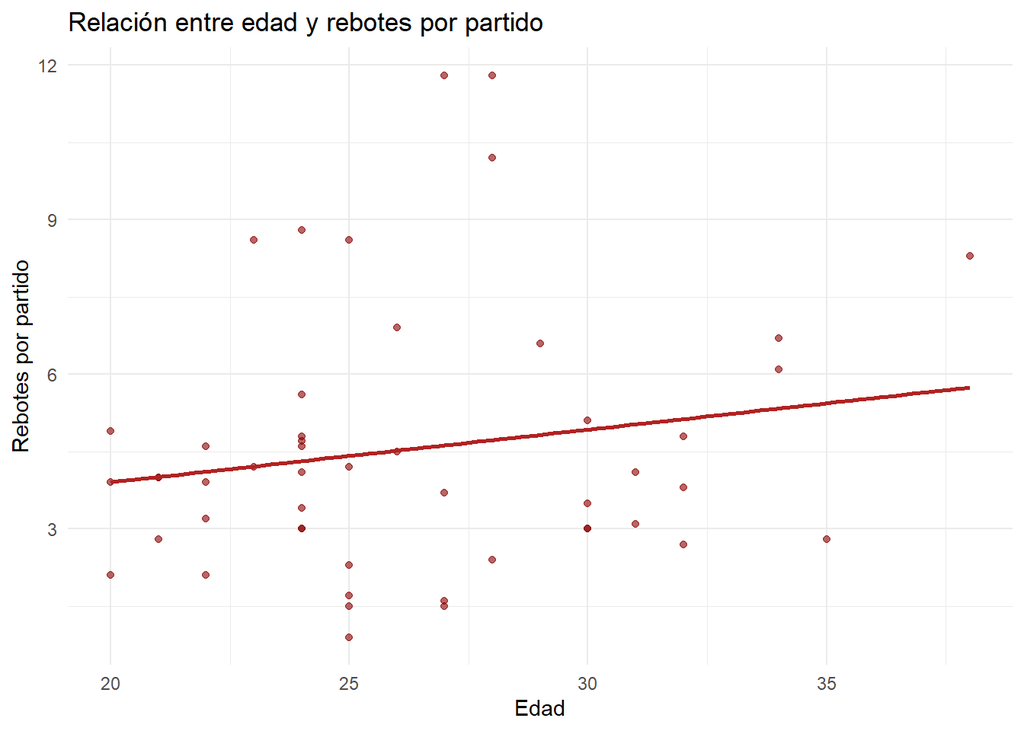

   ```r
   # 3. Rebotes por partido vs. Edad
   ggplot(df, aes(x = age, y = rebounds_per_game)) +
     geom_point(color = "darkred", alpha = 0.6) +
     geom_smooth(method = "lm", se = FALSE, color = "firebrick") +
     theme_minimal() +
     labs(
       title = "Relación entre edad y rebotes por partido",
       x     = "Edad",
       y     = "Rebotes por partido"
     )
   ```

   - **Relación entre los puntos por partido y la edad del jugador**

   La tendencia general es ligeramente ascendente: los jugadores más maduros tienden a promediar algo más de puntos. Sin embargo, hay mucha dispersión, con anotadores de alto volumen tanto en 22 como en 34 años. La pendiente moderada sugiere que la experiencia suma puntos, pero no es determinante.
   - **Relación entre las asistencias por partido y la edad del jugador**

   Se observa un leve aumento de asistencias a medida que sube la edad, aunque con dispersión: algunos bases jóvenes rondan 8–10 asistencias, mientras que jugadores veteranos pueden quedar por debajo de 3. La curva suave indica que, en promedio, los playmakers veteranos reparten más pases, pero no es un patrón muy fuerte.
   - **Relación entre los rebotes por partido y la edad del jugador**

   ```r
   # Filtrar los jugadores de nivel "Elite" y seleccionar su nombre
   elite_players <- df %>%
     filter(nivel_jugador == "Elite") %>%
     select(name)

   # Mostrar los nombres de los jugadores en nivel Elite
   print(elite_players)
   ```

   ```
   ##                    name
   ## 1        Damian Lillard
   ## 2 Giannis Antetokounmpo
   ## 3           Joel Embiid
   ## 4          LeBron James
   ## 5           Luka Dončić
   ## 6          Nikola Jokić
   ## 7         Stephen Curry
   ```

   Los jugadores clasificados en nivel *Elite* son:
   - Damian Lillard
   - Giannis Antetokounmpo
   - Joel Embiid
   - LeBron James
   - Luka Dončić
   - Nikola Jokić
   - Stephen Curry
6. **¿Cómo esta distribuido el rendimiento por minuto por conferencia?**

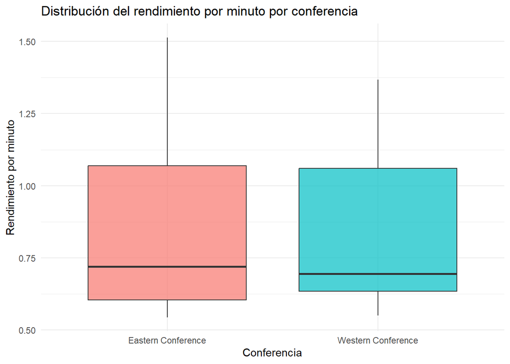

   ```r
   ggplot(df, aes(x = conferencia, y = rendimiento_por_minuto, fill = conferencia)) +
     geom_boxplot(alpha = 0.7) +
     theme_minimal() +
     labs(
       title = "Distribución del rendimiento por minuto por conferencia",
       x     = "Conferencia",
       y     = "Rendimiento por minuto"
     ) +
     theme(legend.position = "none")
   ```

   La distribución del rendimiento por minuto es muy parecida en las dos conferencias: ambas tienen su valor medio cerca de 0.7. La *Eastern* muestra un poco más de variabilidad y algunos jugadores llegan a rendir hasta 1.5, mientras que en la *Western* casi no pasan de 1.3.
7. **¿Qué equipo tiene a los jugadores más jóvenes?**

   ```r
   edad_por_equipo <- df %>%
     group_by(team) %>%
     summarise(
       edad_media = mean(age, na.rm = TRUE)
     ) %>%
     arrange(edad_media)

   # Mostrar el equipo con la menor edad media
   equipo_mas_joven <- edad_por_equipo %>% slice(1)
   print(equipo_mas_joven)
   ```

   ```
   ## # A tibble: 1 × 2
   ##   team            edad_media
   ##   <chr>                <dbl>
   ## 1 Detroit Pistons         20
   ```

   El equipo con los jugadores más jóvenes son los Detroit Pistons (edad media de 20 años).
8. **¿Qué equipo tiene a los jugadores con mayores puntos por partido?**

   ```r
   # Obtener el top 5 de jugadores con más puntos por partido, mostrando nombre, equipo y PPG
   top5_scorers <- df %>%
     arrange(desc(points_per_game)) %>%
     select(name, team, points_per_game) %>%
     head(5)

   # Imprimir el resultado
   print(top5_scorers)
   ```

   ```
   ##                      name                  team points_per_game
   ## 1             Joel Embiid        Boston Celtics            33.1
   ## 2             Luka Dončić      Dallas Mavericks            32.4
   ## 3          Damian Lillard       Milwaukee Bucks            32.2
   ## 4 Shai Gilgeous-Alexander Oklahoma City Thunder            31.4
   ## 5   Giannis Antetokounmpo    Philadelphia 76ers            31.1
   ```

Los cinco máximos anotadores (con su respectivo equipo) son:

- Joel Embiid - Boston Celtics
- Luka Dončić - Dallas Mavericks
- Damian Lillard - Milwaukee Bucks
- Shai Gilgeous-Alexander - Oklahoma City Thunder
- Giannis Antetokounmpo - Philadelphia 76ers

Cada uno pertenece a un equipo distinto, por lo que en este top 5 aparecen cinco equipos diferentes.

# **Clusterización**

Para llevar a cabo la clusterización, hemos decidido utilizar dos métodos distintos. En primer lugar, llevaremos a cabo el método de K-means. Posteriormente, utilizaremos el método jerárquico. Una vez creados los clústers con ambos métodos, decidiremos cuál es el que mejor se adapta a este proyecto.

### **1. Dummificación del dataset**

Para que nuestros modelos puedan incluir las variables cualitativas, hemos decidido dummificarlas.

```r
set.seed(365)

df_cluster <- df[ , !(colnames(df) %in% c("nacionalidad", "nationality", "rendimiento_por_minuto", "nivel_jugador", "team"))]

cat_vars <- setdiff(
  colnames(df_cluster)[sapply(df_cluster, function(x) is.factor(x) || is.character(x))], "name")

df_dummies <- dummy_cols(df_cluster,
                         select_columns = cat_vars,
                         remove_selected_columns = TRUE,
                         remove_first_dummy = FALSE)

num_cols <- sapply(df_dummies, is.numeric) & !grepl("_", names(df_dummies))

df_dummies$name = NULL

num_cols <- c("age", "minutes_played_per_game", "rebounds_per_game", "assists_per_game", "points_per_game")
df_scaled <- scale(df_dummies[ , num_cols])

# Combinar con el resto (las columnas dummy)
df_scaled <- cbind(df_scaled, df_dummies[ , !colnames(df_dummies) %in% num_cols])
```

### **2. Clusterización por K-means**

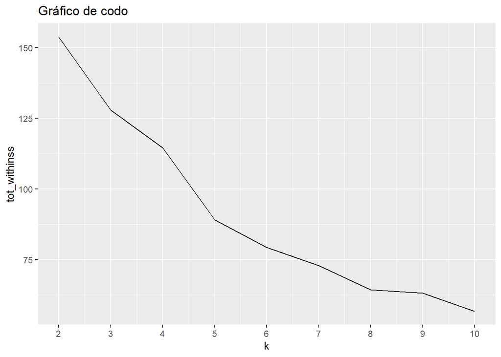

```r
set.seed(365)

tot_withinss <- map_dbl(2:10,  function(k){
  model <- kmeans(x = df_scaled, centers = k)
  model$tot.withinss})

elbow_df <- data.frame(
  k = 2:10 ,
  tot_withinss = tot_withinss)

# Gráfico de codo
ggplot(elbow_df, aes(x = k, y = tot_withinss)) +
  geom_line() +
  labs(title = "Gráfico de codo") +
  scale_x_continuous(breaks = 2:10)
```

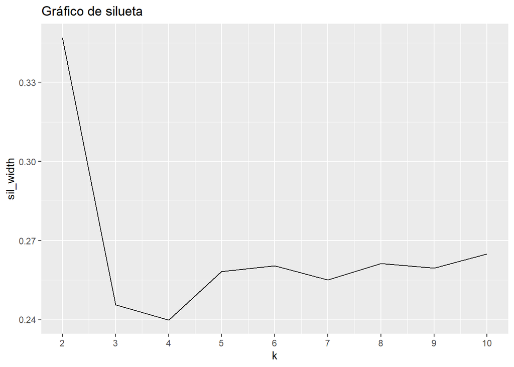

```r
sil_width <- map_dbl(2:10,  function(k){
  model <- pam(x = df_scaled, k = k)
  model$silinfo$avg.width})

sil_df <- data.frame(
  k = 2:10,
  sil_width = sil_width)

# Gráfico de silueta
ggplot(sil_df, aes(x = k, y = sil_width)) +
  geom_line() +
  labs(title = "Gráfico de silueta") +
  scale_x_continuous(breaks = 2:10)
```

En el **gráfico del codo** se observa cómo disminuye el tamaño de los clústers (*tot_withinss*) a medida que aumenta el número de clústers. Aunque la curva presenta una caída constante, por lo que no hay un “codo” como tal, se podría decir que alrededor del punto k = 6, la tasa de disminución comienza a ser menos pronunciada (o menos significativa). Este punto representa un equilibrio adecuado entre la cantidad de clústers y la reducción de la variabilidad interna, lo que sugiere que seis grupos capturan suficientemente la estructura del conjunto de datos sin sobresegmentarlo.

Por otro lado, el **gráfico de silueta** muestra la calidad de la separación entre clústers. Aunque el valor más alto de silueta se da en k = 2, este número sería demasiado bajo para capturar la diversidad del conjunto de jugadores. A partir de k = 5 y especialmente en k = 6, los valores de ancho de silueta se estabilizan (y empiezan a subir ligeramente), manteniéndose alrededor de 0.27, lo que indica una separación aceptable entre clústers.

Por tanto, la elección de 6 clústers representa una elección razonable entre tamaño interno y separación entre clústers, lo que la convierte en la mejor opción tanto desde el punto de vista técnico como interpretativo en el contexto del análisis de rendimiento de jugadores.

```r
set.seed(365)

model_customers <- kmeans(df_scaled, centers = 6)
cluster_k <- model_customers$cluster

segment_customers_k = cbind(df_scaled, cluster_k)
segment_customers_k2 = cbind(df, cluster_k)

df = cbind(df, cluster_k)
df_scaled = cbind(df_scaled, cluster_k)

# Conteo de jugadores por clúster
count(segment_customers_k, cluster_k)
```

```
##   cluster_k  n
## 1         1  7
## 2         2  8
## 3         3 12
## 4         4 11
## 5         5  8
## 6         6  4
```

### **3. Clusterización jerárquica**

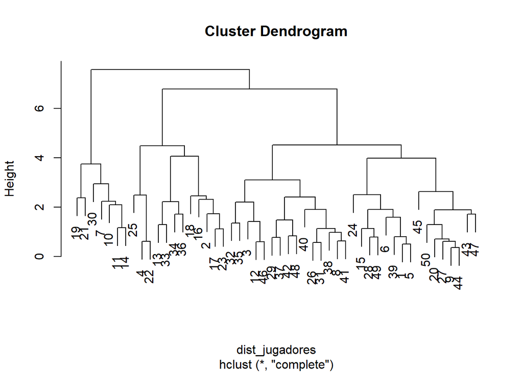

```r
set.seed(365)

# Distancia euclediana entre los jugadores
dist_jugadores <- dist(df_scaled)

hc_jugadores <- hclust(dist_jugadores, method = "complete")

# Dendograma
plot(hc_jugadores)
```

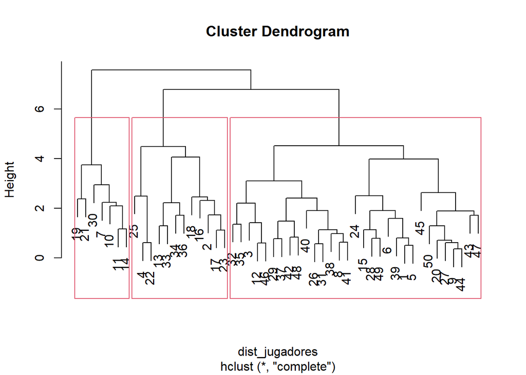

```r
# Separación del dendograma cuando la altura (h) es de 5
plot(hc_jugadores)
rect.hclust(hc_jugadores, h = 5)
```

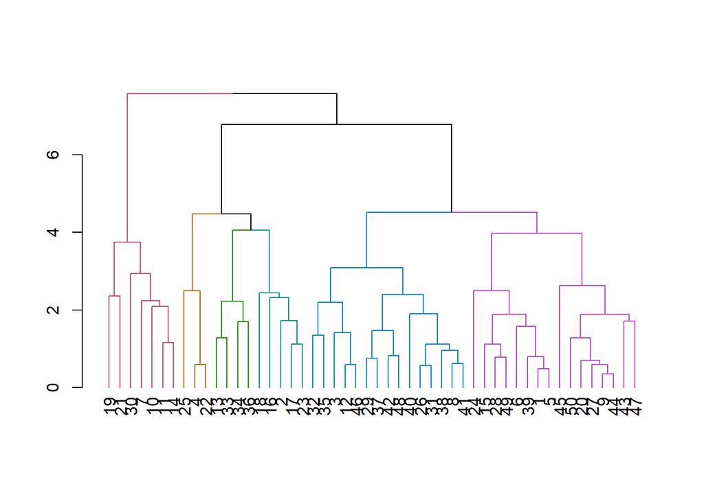

```r
# Separación del dendograma en 6 clústers
dend_jugadores <- as.dendrogram(hc_jugadores)
dend_colored <- color_branches(dend_jugadores, k = 6)
plot(dend_colored)
```

### **4. Elección del método y análisis de clústers**

Finalmente, hemos decidido quedarnos con el método de **clusterización por K-means**. Esta elección se debe a que, al comparar con el enfoque jerárquico, el dendograma no presenta un corte claro que genere seis grupos equilibrados. Las fusiones ocurren a diferentes alturas y, para “forzar” k=6, terminamos agrupando jugadores con perfiles muy dispares, lo que produce clústers desbalanceados y de difícil interpretación. Si bien es cierto que en el modelo jerárquico se podría optar por un número diferente de clústers que los determinados para K-means con el gráfico de codo y de silueta (k=6), creemos que una cantidad menor a 6 clústers no sería adecuada para segmentar correctamente los datos que se tienen (son jugadores bastante variados), mientras que una cantidad mayor podría llevar a una sobresegmentación. Además, aunque en este caso se tienen solo 50 jugadores, si se quisiera llevar esta clusterización a una base de datos de mayor escala, el algoritmo de K-means sería más eficiente. En consecuencia, K-means con seis centros nos permite obtener clústers homogéneos, bien definidos, interpretables y computacionalmente eficientes, adaptados al análisis de rendimiento de jugadores.

Así pues, a continuación de presenta el análisis de los 6 clústers que generamos utilizando dicho método. La exportación de los datos a archivos csv ha sido para realizar análisis complementarios en Excel.

```r
Resumen_K <- df %>%
  group_by(cluster_k) %>%
  summarise(across(where(is.numeric), mean, na.rm = TRUE))

Resumen_K
```

```
## # A tibble: 6 × 7
##   cluster_k   age minutes_played_per_game rebounds_per_game assists_per_game
##       <int> <dbl>                   <dbl>             <dbl>            <dbl>
## 1         1  25.9                    34.8              9.53            5.39
## 2         2  29.4                    16.4              3.54            1.08
## 3         3  22.6                    27.7              4.18            2.38
## 4         4  23.5                    12.5              2.45            0.873
## 5         5  30.2                    35.6              5.41            6.51
## 6         6  31.8                    25.4              3               3.45
## # ℹ 2 more variables: points_per_game <dbl>, rendimiento_por_minuto <dbl>
```

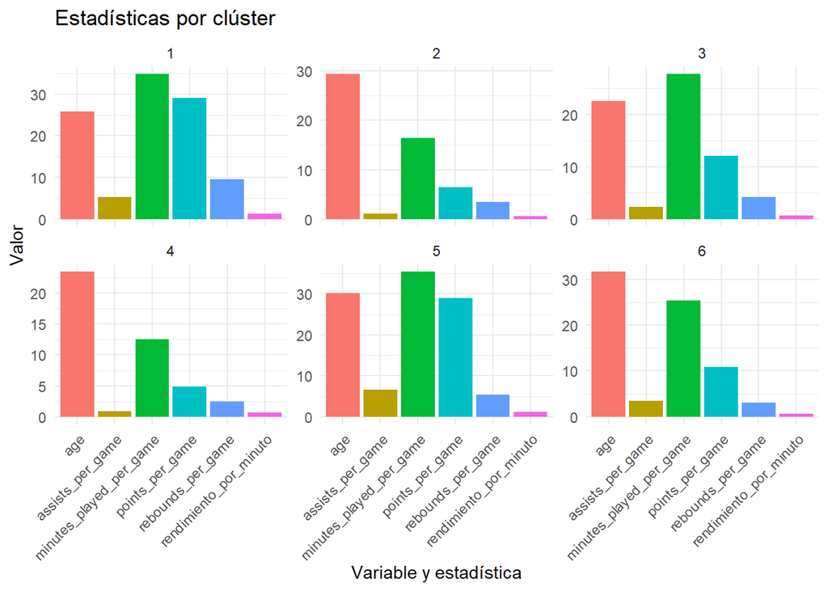

```r
Resumen_K_long <- Resumen_K %>%
  pivot_longer(
    cols = -cluster_k,
    names_to = "nombre_variable",
    values_to = "valor")

ggplot(Resumen_K_long, aes(x = nombre_variable, y = valor, fill = nombre_variable )) +
  geom_bar(stat = "identity", show.legend = FALSE) +
  facet_wrap(~ cluster_k, scales = "free_y") +
  labs(
    title = "Estadísticas por clúster",
    x = "Variable y estadística",
    y = "Valor"
  ) +
  theme_minimal() +
  theme(axis.text.x = element_text(angle = 45, hjust = 1))
```

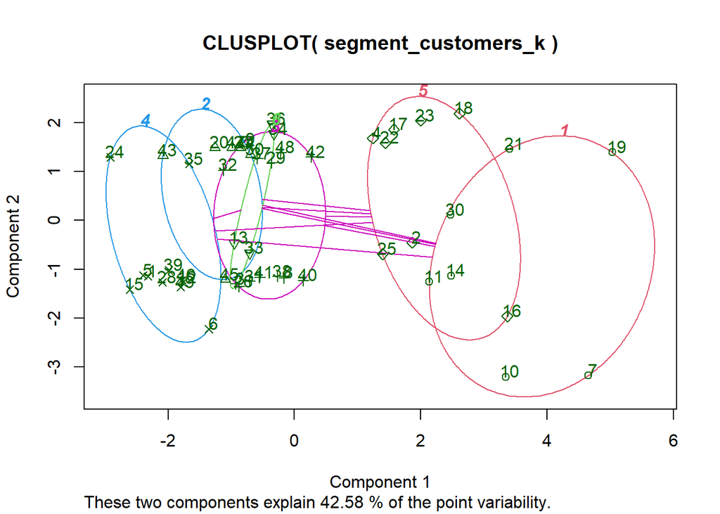

```r
clusplot(segment_customers_k,segment_customers_k$cluster_k,shape=TRUE,color=TRUE,labels=2)
```

```r
write.csv(df, "df_clusterizado.csv", row.names = FALSE, fileEncoding = "latin1")

write.csv(df_scaled, "df_scaled.csv", row.names = FALSE, fileEncoding = "latin1")
```

Estas son las características y atributos que hemos determinado que comparte cada clúster:

**Clúster 6: *Relevo estratégico***